# Data on Solitary Confinement at the Northwest Detention Center

UWCHR

2024-03-14

# Data source

## Notebook goal

This notebook focuses on analysis of segregation records reported by the Northwest ICE Processing Center in Tacoma, WA; also known as the Northwest Detention Center (NWDC), and coded as “TACOMA ICE PROCESSING CENTER (NORTHWEST DET CTR) (WA)” in the below data. Given that this analysis was conducted in response to a breaking news event, it may be updated to reflect ongoing analysis.

```r
library(pacman)
p_load(tidyverse, arrow, lubridate, zoo, digest, ggplot2, plotly, gghighlight, viridis)

df <- read_delim(here::here('analyze', 'input', 'SRMS_spreadsheet_9.1.2018_-_9.1.2023_Redacted.csv.gz'), delim='|',
                      col_types = cols('Placement Date' = col_date(format="%m/%d/%Y"),
                                       'Release Date' = col_date(format="%m/%d/%Y"))) %>%
  drop_na('Tracking Number', 'Facility AOR')

names(df) %<>% stringr::str_replace_all("\\s","_") %>% tolower

nwdc <- "TACOMA ICE PROCESSING CENTER (NORTHWEST DET CTR) (WA)"

# Checking for any variation in SEA AOR facility names; NWDC should be only one present
stopifnot(length(unique(df[df$facility_aor == "SEA (Seattle)", "facility"])) == 1)
```

## Data overview

The HLS/PHR dataset includes a total of 14251 SMRS placement records for 126 U.S. ICE detention facilities. For a full description of the dataset, see the [full report](https://phr.org/our-work/resources/endless-nightmare-solitary-confinement-in-us-immigration-detention).

The dataset includes a total of 419 SRMS placement records for the Northwest Detention Center (NWDC) in Tacoma, WA.

## Death of Charles Leo Daniel at NWDC

On March 7, 2024, the death of Charles Leo Daniel was reported at Northwest Detention Center (NWDC). Daniel, a citizen of Trinidad and Tobago, was reportedly in segregation at the time of his death. Other ICE records reveal that Daniel was booked in to the NWDC on April 2, 2020, and that he was the only citizen of Trinidad and Tobago to be detained at the facility from his arrival in 2020 until August 15, 2022. Therefore, we conclude that the two ICE SRMS records in the HLS dataset for a male citizen of Trinidad and Tobago at NWDC represent Daniel’s segregation history while detained at the facility. The full records are presented below (note redaction of some values):

```r
nwdc_trin <- df %>%
  filter(str_detect(facility, "TACOMA"),
         country_of_citizenship == 'TRINIDAD AND TOBAGO') %>%
  mutate(placement_date = as.character(placement_date),
         release_date = as.character(release_date))

transpose_df <- function(df) {
  t_df <- data.table::transpose(df)
  colnames(t_df) <- rownames(df)
  rownames(t_df) <- colnames(df)
  t_df <- t_df %>%
    tibble::rownames_to_column(.data = .) %>%
    tibble::as_tibble(.)
  return(t_df)
}

knitr::kable(transpose_df(nwdc_trin) %>%
               rename(column = rowname,
                      placement_1 = "1",
                      placement_2 = "2"),
             caption = "NWDC SRMS records for citizens of Trinindad and Tobago")
```

NWDC SRMS records for citizens of Trinindad and Tobago

| column | placement_1 | placement_2 |
| --- | --- | --- |
| tracking_number | (b)(7)(E) | (b)(7)(E) |
| alien_number | (b)(6), (b)(7)(C) | (b)(6), (b)(7)(C) |
| gender | Male | Male |
| country_of_citizenship | TRINIDAD AND TOBAGO | TRINIDAD AND TOBAGO |
| facility_aor | SEA (Seattle) | SEA (Seattle) |
| facility | TACOMA ICE PROCESSING CENTER (NORTHWEST DET CTR) (WA) | TACOMA ICE PROCESSING CENTER (NORTHWEST DET CTR) (WA) |
| report_type | 14 Day | 72 Hour |
| placement_date | 2020-04-16 | 2021-06-25 |
| placement_reason | Detainee Request: Other | Protective Custody |
| release_date | 2021-06-23 | NA |
| detailed_placement_reason | (b)(7)(E)(b)(6)(b)(7)(C) | (b)(7)(E)(b)(6)(b)(7)(C) |
| attorney_of_record | No | No |
| attorney_notification | No | No |
| detainee_request_segregation | Detainee Request | Detainee Request |
| compliance_with_detention_standards | Yes | Yes |
| mental_illness | Serious Mental Illness | Serious Mental Illness |
| serious_medical_illness | No | No |
| serious_disability | No | No |
| smi_spi_dis_description | (b)(6), (b)(7)(C) | (b)(6), (b)(7)(C) |
| fo_recommendation | (b)(6), (b)(7)(C) | (b)(6), (b)(7)(C) |
| created | 5/5/2020 14:42 | 7/7/2021 17:42 |
| length_of_stay | 433 | 811 |
| suicide_risk? | NA | NA |

The first solitary placement began on 2020-04-16, shortly after Daniel was booked into the NWDC and lasted until 2021-06-23, or 433 days. The second solitary placement began two days later on 2021-06-25 and was ongoing at the time of release of the HLS data in mid-September 2023, or at least 811 days. (As noted in the replication data for the HLS/PHR report, ongoing solitary placements were dropped from analysis for the published report; we include these records here due to their relevance to issues at the NWDC.)

As noted, both stays were reported by ICE as “Detainee Request”, with the second stay categorized as “Protective Custody”. Both stays are also flagged as “Serious Mental Illness”.

As seen below, Daniel’s second placement of at least 811 days was the second longest individual solitary placement reported nationally during the time period covered by the HLS dataset. As seen below, the longest individual placement reported nationally was also at NWDC and was also ongoing at the time of release of the dataset. (Because unique personal identifiers are not included in this dataset, it is not possible to calculate cumulative stay length per person across individual solitary placements.)

```r
t1 <- df %>%
  mutate(ongoing_stay = is.na(release_date)) %>%
  dplyr::select(country_of_citizenship, facility, length_of_stay, ongoing_stay) %>%
  arrange(desc(length_of_stay)) %>%
  head(10) %>%
  knitr::kable(caption = "Top 10 longest solitary placements nationwide, Sept. 2018-Sept. 2023",
               row.names = TRUE)

t1
```

Top 10 longest solitary placements nationwide, Sept. 2018-Sept. 2023

|  | country_of_citizenship | facility | length_of_stay | ongoing_stay |
| --- | --- | --- | --- | --- |
| 1 | EL SALVADOR | TACOMA ICE PROCESSING CENTER (NORTHWEST DET CTR) (WA) | 817 | TRUE |
| 2 | TRINIDAD AND TOBAGO | TACOMA ICE PROCESSING CENTER (NORTHWEST DET CTR) (WA) | 811 | TRUE |
| 3 | MEXICO | OTAY MESA DETENTION CENTER (SAN DIEGO CDF) (CA) | 759 | FALSE |
| 4 | UZBEKISTAN | DENVER CONTRACT DETENTION FACILITY (CO) | 727 | FALSE |
| 5 | HAITI | BUFFALO (BATAVIA) SERVICE PROCESSING CENTER (NY) | 652 | FALSE |
| 6 | GUATEMALA | TACOMA ICE PROCESSING CENTER (NORTHWEST DET CTR) (WA) | 637 | FALSE |
| 7 | MEXICO | OTAY MESA DETENTION CENTER (SAN DIEGO CDF) (CA) | 567 | FALSE |
| 8 | RUSSIA | TACOMA ICE PROCESSING CENTER (NORTHWEST DET CTR) (WA) | 559 | FALSE |
| 9 | MEXICO | TACOMA ICE PROCESSING CENTER (NORTHWEST DET CTR) (WA) | 550 | FALSE |
| 10 | RUSSIA | KROME NORTH SERVICE PROCESSING CENTER (FL) | 534 | TRUE |

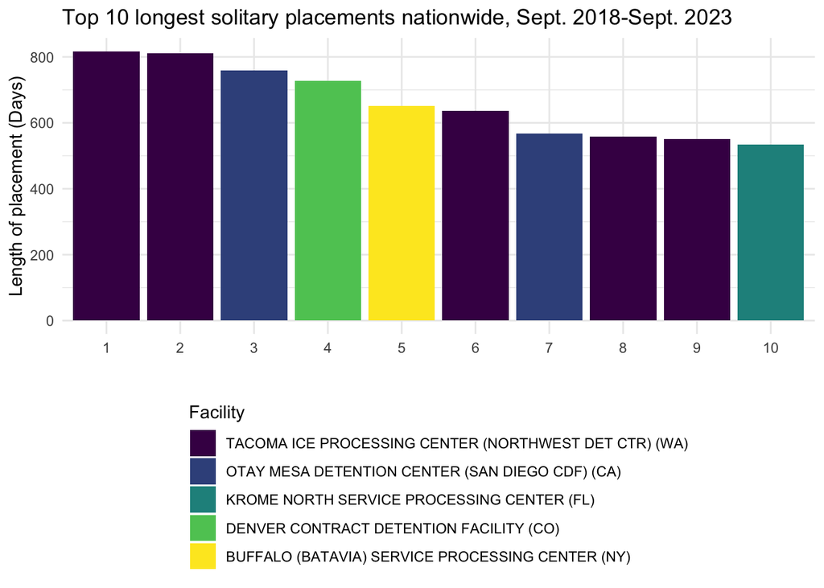

```r
p1 <- df %>%
  dplyr::select(country_of_citizenship, facility, length_of_stay) %>%
  arrange(desc(length_of_stay)) %>%
  mutate(rank = row_number()) %>%
  head(10) %>%
  ggplot(aes(x=as.factor(rank), y=length_of_stay, fill=facility)) +
  geom_col() +
  # scale_x_discrete(limits=rev) +
  scale_fill_viridis_d(direction=-1, breaks=rev) +
  # gghighlight(facility == nwdc) +
  labs(title = "Top 10 longest solitary placements nationwide, Sept. 2018-Sept. 2023",
       fill = "Facility") +
  ylab("Length of placement (Days)") +
  xlab("") +
  theme_minimal() +
  theme(legend.position = "bottom",
        legend.direction = 'vertical')

p1
```

## Comparison of solitary placement lengths

In fact, solitary placements reported to SRMS at the Northwest ICE Process Center were significantly longer on average than nationally, with an average stay length of 58.947494 days compared to a national average of 27.0286296 days, and a median stay length of 27 days compared to a national median of 15 days:

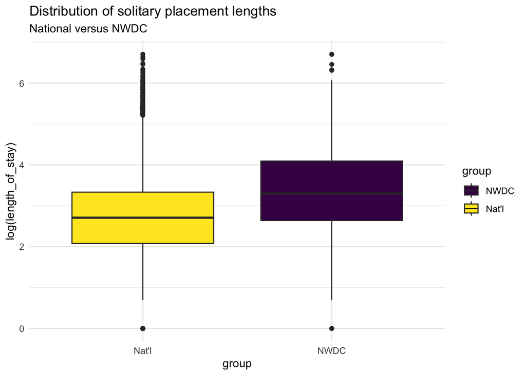

```r
df_nwdc <- df %>%
  filter(facility == nwdc) %>%
  mutate(group = "NWDC")

df_all <- df %>%
  mutate(group = "Nat'l")

dat <- rbind(df_nwdc, df_all) %>%
  mutate(group = as.factor(group))

b1 <- dat %>%
  group_by(group) %>%
  ggplot(aes(x = group, y = log(length_of_stay), fill=group)) +
  geom_boxplot() +
  scale_fill_viridis_d(direction=-1, breaks=rev) +
  scale_x_discrete() +
  theme_minimal() +
  labs(title = "Distribution of solitary placement lengths",
       subtitle = "National versus NWDC")

b1
```

## Special vulnerabilities

SRMS placements are flagged for “special vulnerability” categories, noted in the dataset as “Mental Illness”, “Serious Medical Illness”, “Serious Disability”, and “Suicide Risk?”.

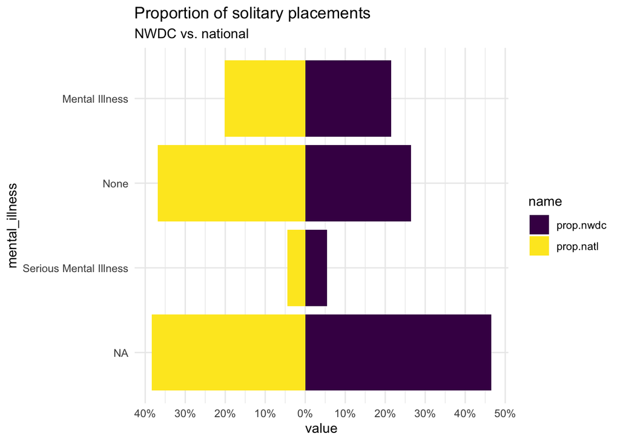

```r
# Standardize one bad value
df <- df %>%
  mutate(mental_illness = case_when(mental_illness == "Yes" ~ "Mental Illness",
                                    TRUE ~ mental_illness))

mi_nwdc <- df %>%
  filter(facility == nwdc) %>%
  count(mental_illness) %>%
  mutate(prop = n / sum(n)) %>%
  ungroup()

mi_natl <- df %>%
  count(mental_illness) %>%
  mutate(prop = n / sum(n)) %>%
  ungroup()

dat <- left_join(mi_natl, mi_nwdc, by='mental_illness', suffix=c(".natl", ".nwdc")) %>%
  pivot_longer(cols=-c('mental_illness')) %>%
  filter(str_detect(name, "prop")) %>%
  mutate(value = case_when(name == "prop.natl" ~ -value,
                   name == "prop.nwdc" ~ value))

mi_prop_range <- range(dat$value)
mi_prop_range_breaks <- pretty(dat$value, 10)

p1 <- dat %>%
  ggplot(aes(x = value, y = mental_illness, fill=name), color = 'black') +
    geom_col() +
    scale_fill_viridis_d(limits=rev) +
    scale_y_discrete(limits=rev) +
    scale_x_continuous(
      breaks = mi_prop_range_breaks,
      labels = function(x) scales::percent(abs(x))) +
  labs(title = "Proportion of solitary placements",
       subtitle = "NWDC vs. national") +
  theme_minimal()

p1
```

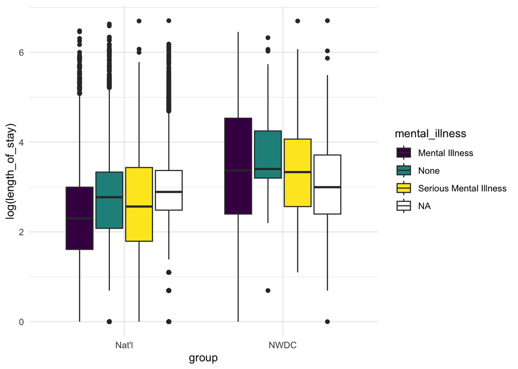

```r
df_nwdc <- df %>%
  filter(facility == nwdc) %>%
  mutate(group = "NWDC")

df_all <- df %>%
  mutate(group = "Nat'l")

dat <- rbind(df_nwdc, df_all) %>%
  mutate(group = as.factor(group))

b1 <- dat %>%
  ggplot(aes(x = group, y = log(length_of_stay), fill = mental_illness)) +
  geom_boxplot() +
  scale_fill_viridis_d() +
  theme_minimal()

b1
```

```r
df_nwdc <- df %>%
  filter(facility == nwdc) %>%
  mutate(group = "NWDC")

df_all <- df %>%
  mutate(group = "Nat'l")

dat <- rbind(df_nwdc, df_all) %>%
  mutate(group = as.factor(group))

dat %>%
  count(group, serious_medical_illness)
```

```
## # A tibble: 6 × 3
##   group serious_medical_illness     n
##   <fct> <chr>                   <int>
## 1 Nat'l No                       7830
## 2 Nat'l Yes                       938
## 3 Nat'l <NA>                     5483
## 4 NWDC  No                        208
## 5 NWDC  Yes                        15
## 6 NWDC  <NA>                      196
```

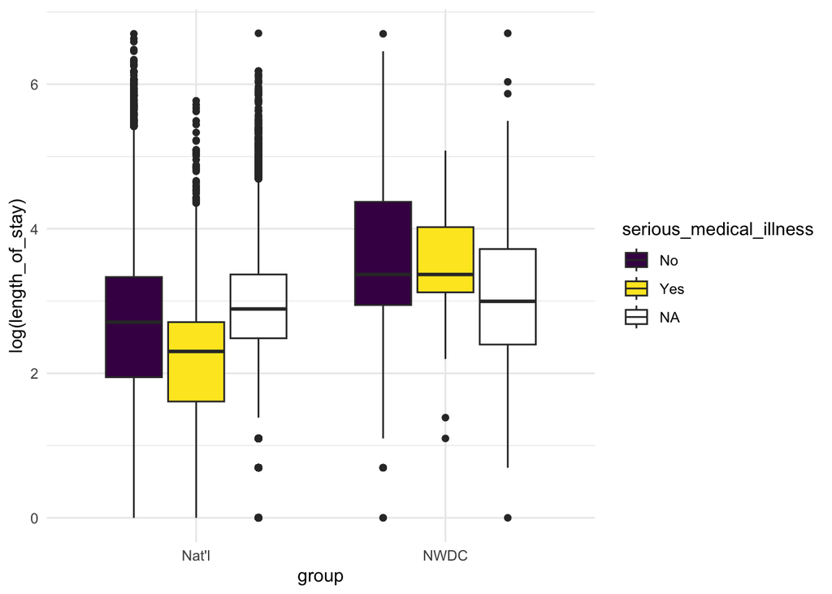

```r
b1 <- dat %>%
  ggplot(aes(x = group, y = log(length_of_stay), fill = serious_medical_illness) )+
  geom_boxplot() +
  scale_fill_viridis_d() +
  theme_minimal()

b1
```

```r
df_nwdc <- df %>%
  filter(facility == nwdc) %>%
  mutate(group = "NWDC")

df_all <- df %>%
  mutate(group = "Nat'l")

dat <- rbind(df_nwdc, df_all) %>%
  mutate(group = as.factor(group))

dat %>%
  count(group, serious_disability)
```

```
## # A tibble: 6 × 3
##   group serious_disability     n
##   <fct> <chr>              <int>
## 1 Nat'l No                  8639
## 2 Nat'l Yes                  129
## 3 Nat'l <NA>                5483
## 4 NWDC  No                   222
## 5 NWDC  Yes                    1
## 6 NWDC  <NA>                 196
```

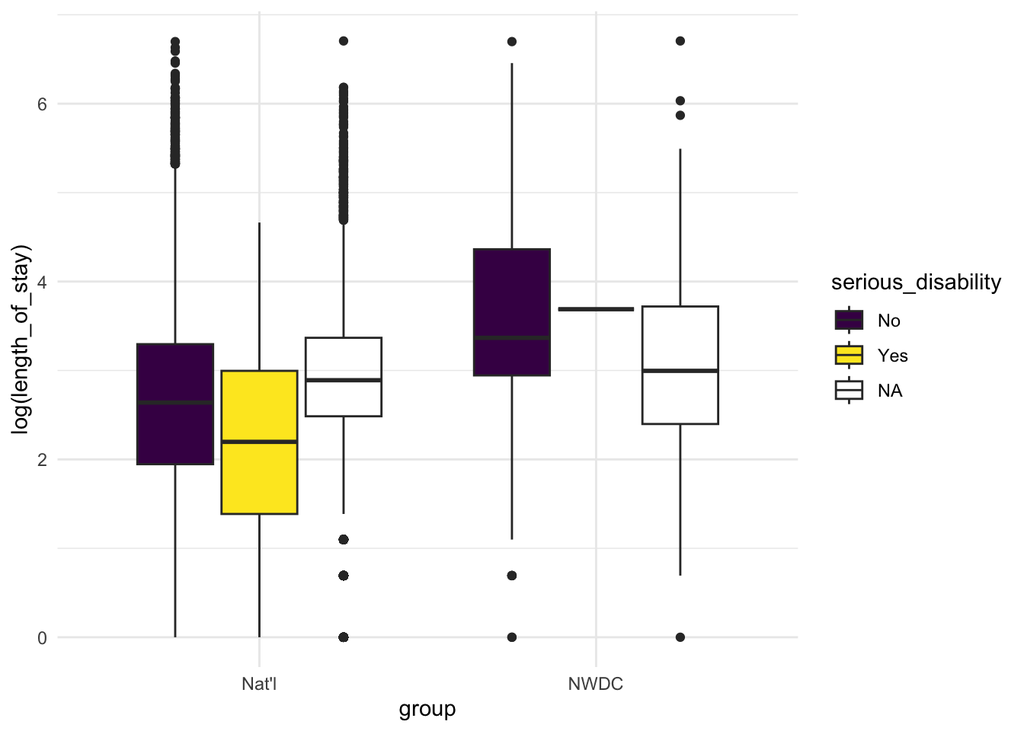

```r
b1 <- dat %>%
  ggplot(aes(x = group, y = log(length_of_stay), fill = serious_disability) )+
  geom_boxplot() +
  scale_fill_viridis_d() +
  theme_minimal()

b1
```

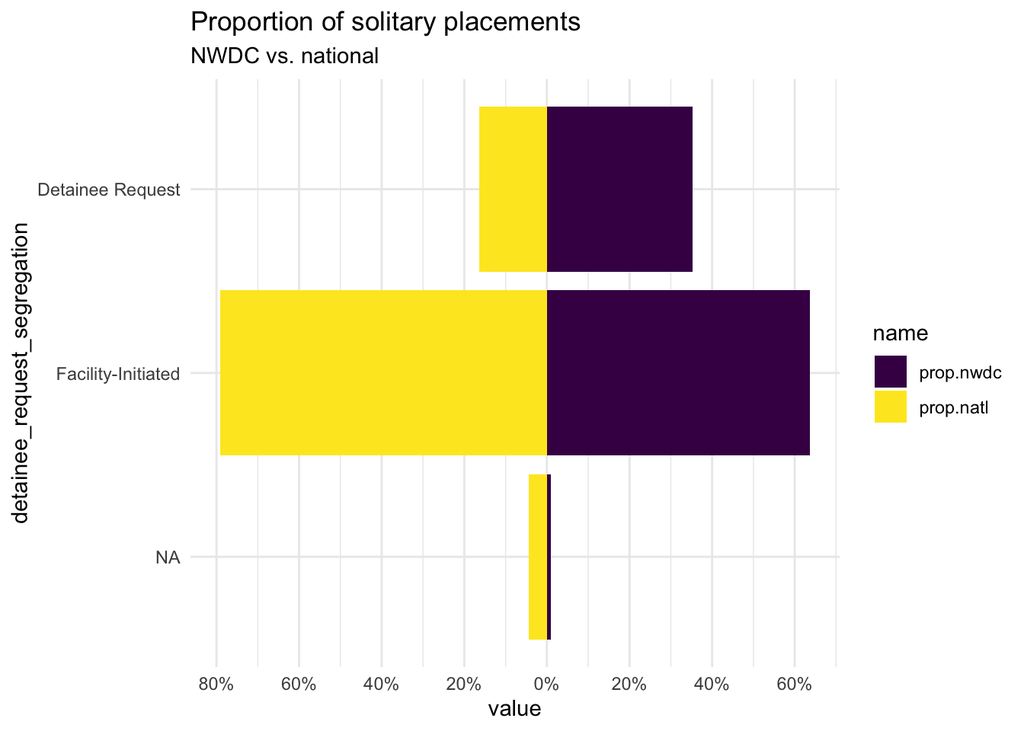

```r
dr_nwdc <- df %>%
  filter(facility == nwdc) %>%
  count(detainee_request_segregation) %>%
  mutate(prop = n / sum(n)) %>%
  ungroup()

dr_natl <- df %>%
  count(detainee_request_segregation) %>%
  mutate(prop = n / sum(n)) %>%
  ungroup()

dat <- left_join(dr_natl, dr_nwdc, by='detainee_request_segregation', suffix=c(".natl", ".nwdc")) %>%
  pivot_longer(cols=-c('detainee_request_segregation')) %>%
  filter(str_detect(name, "prop")) %>%
  mutate(value = case_when(name == "prop.natl" ~ -value,
                   name == "prop.nwdc" ~ value))

dr_prop_range <- range(dat$value)
dr_prop_range_breaks <- pretty(dat$value, 10)

p1 <- dat %>%
  ggplot(aes(x = value, y = detainee_request_segregation, fill=name), color = 'black') +
    geom_col() +
    scale_fill_viridis_d(limits=rev) +
    scale_y_discrete(limits=rev) +
    scale_x_continuous(
      breaks = dr_prop_range_breaks,
      labels = function(x) scales::percent(abs(x))) +
  labs(title = "Proportion of solitary placements",
       subtitle = "NWDC vs. national") +
  theme_minimal()

p1
```

## Detainee request

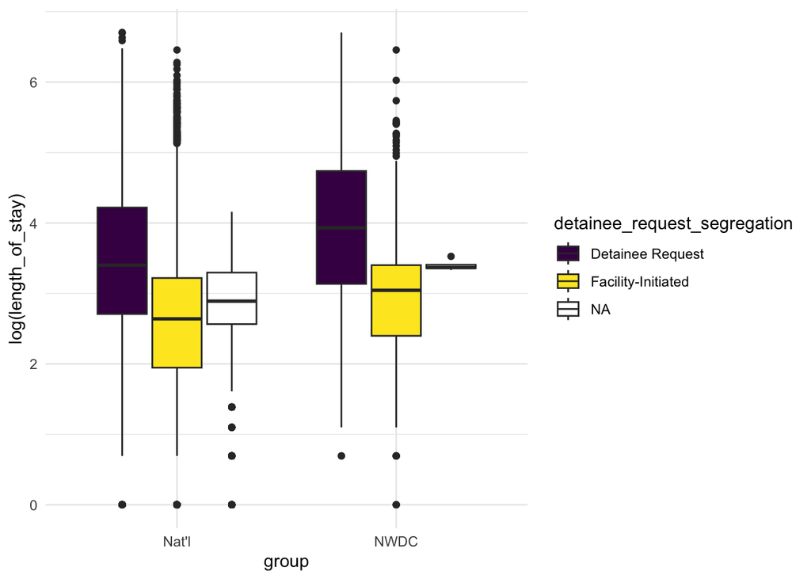

```r
df_nwdc <- df %>%
  filter(facility == nwdc) %>%
  mutate(group = "NWDC")

df_all <- df %>%
  mutate(group = "Nat'l")

dat <- rbind(df_nwdc, df_all) %>%
  mutate(group = as.factor(group))

b1 <- dat %>%
  ggplot(aes(x = group, y = log(length_of_stay), fill = detainee_request_segregation)) +
  geom_boxplot() +
  scale_fill_viridis_d() +
  theme_minimal()

b1
```

## Placement reason

Note no placements categorized as “Hunger Strike”, “Mental Illness” (some “Medical/Mental”), or “Suicide Risk” at NWDC. Note several of these categories are not mutually-exclusive.

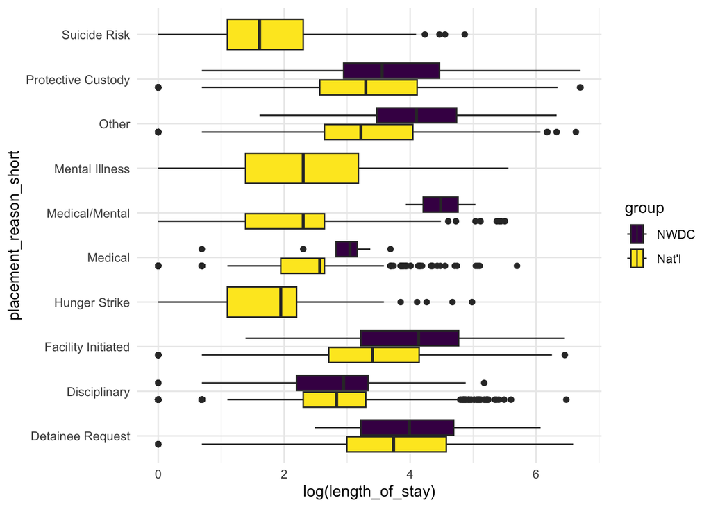

```r
df <- df %>%
  mutate(placement_reason_short = case_when(
    str_detect(placement_reason, "Detainee Request: Other") ~ "Detainee Request",
    str_detect(placement_reason, "Disciplinary") ~ "Disciplinary",
    str_detect(placement_reason, "Facility Initiated: Other") ~ "Facility Initiated",
    str_detect(placement_reason, "Facility Security Threat") ~ "Facility Initiated",
    str_detect(placement_reason, "Facility Security Threat: Due to Seriousness of Criminal Conviction") ~ "Facility Initiated",
    str_detect(placement_reason, "Facility Security Threat: Gang Member Status (Not Protective Custody)") ~ "Facility Initiated",
    str_detect(placement_reason, "Facility Security Threat: Other") ~ "Facility Initiated",
    str_detect(placement_reason, "Facility Security Threat: Violent or Disruptive Behavior") ~ "Facility Initiated",
    str_detect(placement_reason, "Hunger Strike") ~ "Hunger Strike",
    str_detect(placement_reason, "Medical/Mental") ~ "Medical/Mental",
    str_detect(placement_reason, "Medical: Detox/Withdrawal Observation") ~ "Medical",
    str_detect(placement_reason, "Medical: Disabled or Infirm") ~ "Medical",
    str_detect(placement_reason, "Medical: Observation") ~ "Medical",
    str_detect(placement_reason, "Medical: Other Infectious Disease") ~ "Medical",
    str_detect(placement_reason, "Medical: Other") ~ "Medical",
    str_detect(placement_reason, "Medical: Segregation Unit") ~ "Medical",
    str_detect(placement_reason, "Medical: Tuberculosis") ~ "Medical",
    str_detect(placement_reason, "Mental Illness") ~ "Mental Illness",
    str_detect(placement_reason, "Mental Illness: Observation") ~ "Mental Illness",
    str_detect(placement_reason, "Other") ~ "Other",
    str_detect(placement_reason, "Other: Pending General Population Bedspace Availability") ~ "Other",
    str_detect(placement_reason, "Other: Unique Reason Not Listed (Explain in Comments)") ~ "Other",
    str_detect(placement_reason, "Pending Investigation of Disciplinary Violation") ~ "Pending Disciplinary",
    str_detect(placement_reason, "Protective Custody") ~ "Protective Custody",
    str_detect(placement_reason, "Protective Custody: Criminal Offense (i.e. Sex Offender)") ~ "Protective Custody",
    str_detect(placement_reason, "Protective Custody: Gang Status (Protective Custody Only)") ~ "Protective Custody",
    str_detect(placement_reason, "Protective Custody: Lesbian, Gay, Bisexual, Transgender (LGBT)") ~ "Protective Custody",
    str_detect(placement_reason, "Protective Custody: Other Detainee Safety") ~ "Protective Custody",
    str_detect(placement_reason, "Protective Custody: Special Vulnerability Other") ~ "Protective Custody",
    str_detect(placement_reason, "Protective Custody: Victim of Sexual Assault") ~ "Protective Custody",
    str_detect(placement_reason, "Suicide Risk Placement") ~ "Suicide Risk"
  ))

df_nwdc <- df %>%
  filter(facility == nwdc) %>%
  mutate(group = "NWDC")

df_all <- df %>%
  mutate(group = "Nat'l")

dat <- rbind(df_nwdc, df_all)

b1 <- dat %>%
  ggplot(aes(y = placement_reason_short, x = log(length_of_stay), fill = group)) +
  geom_boxplot() +
  scale_fill_viridis_d(limits=rev) +
  theme_minimal()

b1
```

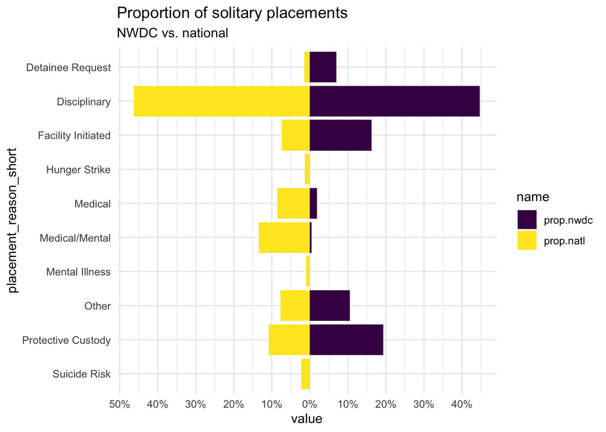

```r
dr_nwdc <- df %>%
  filter(facility == nwdc) %>%
  count(placement_reason_short) %>%
  mutate(prop = n / sum(n)) %>%
  ungroup()

dr_natl <- df %>%
  count(placement_reason_short) %>%
  mutate(prop = n / sum(n)) %>%
  ungroup()

dat <- left_join(dr_natl, dr_nwdc, by='placement_reason_short', suffix=c(".natl", ".nwdc")) %>%
  pivot_longer(cols=-c('placement_reason_short')) %>%
  filter(str_detect(name, "prop")) %>%
  mutate(value = case_when(name == "prop.natl" ~ -value,
                   name == "prop.nwdc" ~ value))

dr_prop_range <- range(dat$value)
dr_prop_range_breaks <- pretty(dat$value, 10)

p1 <- dat %>%
  ggplot(aes(x = value, y = placement_reason_short, fill=name), color = 'black') +
    geom_col() +
    scale_fill_viridis_d(limits=rev) +
    scale_y_discrete(limits=rev) +
    scale_x_continuous(
      breaks = dr_prop_range_breaks,
      labels = function(x) scales::percent(abs(x))) +
  labs(title = "Proportion of solitary placements",
       subtitle = "NWDC vs. national") +
  theme_minimal()

p1
```